```r
library(C50)
data(churn)
```

Combining/merging two data sets churnTest and churnTrain to form one table i.e. churn

```r
churn <- rbind(churnTest, churnTrain)
```

checking proprtion of customer leaving or retaining the services

```r
prop.table(table(churn$churn )) #gives the proportion
```

```
##
##    yes     no
## 0.1414 0.8586
```

```r
table(churn$churn) #gives the number of YES and the number of NO
```

```
##
##  yes   no
##  707 4293
```

707 (~14%) customers who churned. visualizing outlier or wrong data enteriesi.e. Very low or high variance,errors,missing data.

```r
summary(churn)
```

```
##      state      account_length          area_code    international_plan
##  WV     : 158   Min.   :  1.0   area_code_408:1259   no :4527
##  MN     : 125   1st Qu.: 73.0   area_code_415:2495   yes: 473
##  AL     : 124   Median :100.0   area_code_510:1246
##  ID     : 119   Mean   :100.3
##  VA     : 118   3rd Qu.:127.0
##  OH     : 116   Max.   :243.0
##  (Other):4240
##  voice_mail_plan number_vmail_messages total_day_minutes total_day_calls
##  no :3677        Min.   : 0.000        Min.   :  0.0     Min.   :  0
##  yes:1323        1st Qu.: 0.000        1st Qu.:143.7     1st Qu.: 87
##                  Median : 0.000        Median :180.1     Median :100
##                  Mean   : 7.755        Mean   :180.3     Mean   :100
##                  3rd Qu.:17.000        3rd Qu.:216.2     3rd Qu.:113
##                  Max.   :52.000        Max.   :351.5     Max.   :165
##
##  total_day_charge total_eve_minutes total_eve_calls total_eve_charge
##  Min.   : 0.00    Min.   :  0.0     Min.   :  0.0   Min.   : 0.00
##  1st Qu.:24.43    1st Qu.:166.4     1st Qu.: 87.0   1st Qu.:14.14
##  Median :30.62    Median :201.0     Median :100.0   Median :17.09
##  Mean   :30.65    Mean   :200.6     Mean   :100.2   Mean   :17.05
##  3rd Qu.:36.75    3rd Qu.:234.1     3rd Qu.:114.0   3rd Qu.:19.90
##  Max.   :59.76    Max.   :363.7     Max.   :170.0   Max.   :30.91
##
##  total_night_minutes total_night_calls total_night_charge
##  Min.   :  0.0       Min.   :  0.00    Min.   : 0.000
##  1st Qu.:166.9       1st Qu.: 87.00    1st Qu.: 7.510
##  Median :200.4       Median :100.00    Median : 9.020
##  Mean   :200.4       Mean   : 99.92    Mean   : 9.018
##  3rd Qu.:234.7       3rd Qu.:113.00    3rd Qu.:10.560
##  Max.   :395.0       Max.   :175.00    Max.   :17.770
##
##  total_intl_minutes total_intl_calls total_intl_charge
##  Min.   : 0.00      Min.   : 0.000   Min.   :0.000
##  1st Qu.: 8.50      1st Qu.: 3.000   1st Qu.:2.300
##  Median :10.30      Median : 4.000   Median :2.780
##  Mean   :10.26      Mean   : 4.435   Mean   :2.771
##  3rd Qu.:12.00      3rd Qu.: 6.000   3rd Qu.:3.240
##  Max.   :20.00      Max.   :20.000   Max.   :5.400
##
##  number_customer_service_calls churn
##  Min.   :0.00                  yes: 707
##  1st Qu.:1.00                  no :4293
##  Median :1.00
##  Mean   :1.57
##  3rd Qu.:2.00
##  Max.   :9.00
##
```

Removing State, area_code, and account_length attributes,as they are not appropriate for classification features:

```r
myvars <- names(churn) %in% c('state','area_code','account_length')
Churn_new <- churn[!myvars]
```

Converting character variables to integer variables using dummyvar function:

```r
library(caret)
dummmy <- dummyVars(' ~ .', data = Churn_new, fullRank=T) #FullRank-factor column comprised of two levels
Churn_new <- data.frame(predict(dummmy, newdata = Churn_new))
```

Applying factor variables

```r
names <- c('international_plan.yes' ,'voice_mail_plan.yes','churn.no')
Churn_new[,names] <- lapply(Churn_new[,names] , factor)
```

Removing the near zero variance variable

```r
dim(Churn_new)
```

```
## [1] 5000   17
```

```r
nzv <- nearZeroVar(Churn_new)
filtered_churn <- Churn_new [, -nzv]  #Removes the nzv variable
str(filtered_churn)
```

```
## 'data.frame':    5000 obs. of  16 variables:
##  $ international_plan.yes       : Factor w/ 2 levels "0","1": 1 1 1 1 1 1 1 1 1 1 ...
##  $ voice_mail_plan.yes          : Factor w/ 2 levels "0","1": 1 1 2 1 1 1 2 1 1 2 ...
##  $ total_day_minutes            : num  70.9 223.6 294.7 216.8 197.4 ...
##  $ total_day_calls              : num  123 86 95 123 78 85 124 97 117 100 ...
##  $ total_day_charge             : num  12.1 38 50.1 36.9 33.6 ...
##  $ total_eve_minutes            : num  212 245 237 126 124 ...
##  $ total_eve_calls              : num  73 139 105 88 101 68 125 112 46 89 ...
##  $ total_eve_charge             : num  18 20.8 20.2 10.7 10.5 ...
##  $ total_night_minutes          : num  236 94.2 300.3 220.6 204.5 ...
##  $ total_night_calls            : num  73 81 127 82 107 90 120 106 71 92 ...
##  $ total_night_charge           : num  10.62 4.24 13.51 9.93 9.2 ...
##  $ total_intl_minutes           : num  10.6 9.5 13.7 15.7 7.7 6.9 12.9 11.1 9.9 11.9 ...
##  $ total_intl_calls             : num  3 7 6 2 4 5 3 6 4 1 ...
##  $ total_intl_charge            : num  2.86 2.57 3.7 4.24 2.08 1.86 3.48 3 2.67 3.21 ...
##  $ number_customer_service_calls: num  3 0 1 1 2 1 1 0 2 0 ...
##  $ churn.no                     : Factor w/ 2 levels "0","1": 2 2 2 2 2 2 2 2 2 2 ...
```

Checking corellation,corellation refers to the extent to which two variables have a linear relationship with each other.

```r
library(magrittr)
library(dplyr)
d.num <- filtered_churn %>% select (which(sapply(filtered_churn, is.numeric)))
# only numeric features
high.corr.num <- findCorrelation(cor(d.num), cutoff = .75)
names(d.num)[high.corr.num]
```

```
## [1] "total_night_minutes" "total_intl_charge"   "total_day_charge"
## [4] "total_eve_charge"
```

```r
myvars1 <- names(filtered_churn ) %in% c('total_night_calls','total_night_minutes' ,'total_eve_minutes', 'number_customer_service_calls')
filtered_churn <-filtered_churn[!myvars1]
```

data splitting: we divide in the ratio train:test as 70:30

```r
set.seed(123)
d = sample(2,nrow(filtered_churn), replace = TRUE , prob = c(0.7,0.3))
trainset = filtered_churn[d == 1,]
testset = filtered_churn[d == 2,]
dim(trainset)
```

```
## [1] 3513   12
```

```r
library(party)
library(partykit)
```

[figure not shown]

```r
diabTree <- ctree(churn.no ~ ., data = filtered_churn )
plot(diabTree)
```

```r
predicted.filtered_churn = predict(diabTree)
tab <- table(real = filtered_churn$churn.no, predicted = predicted.filtered_churn)
```

Accuracy :

```r
mean(filtered_churn$churn.no == predict(diabTree))
```

```
## [1] 0.9308
```

```r
sum(diag(tab)) / sum(tab)
```

```
## [1] 0.9308
```

```r
library(gmodels)
ctab <-CrossTable(filtered_churn$churn.no,predicted.filtered_churn)
```

```
##
##
##    Cell Contents
## |-------------------------|
## |                       N |
## | Chi-square contribution |
## |           N / Row Total |
## |           N / Col Total |
## |         N / Table Total |
## |-------------------------|
##
##
## Total Observations in Table:  5000
##
##
##                         | predicted.filtered_churn
## filtered_churn$churn.no |         0 |         1 | Row Total |
## ------------------------|-----------|-----------|-----------|
##                       0 |       383 |       324 |       707 |
##                         |  1852.760 |   163.301 |           |
##                         |     0.542 |     0.458 |     0.141 |
##                         |     0.946 |     0.071 |           |
##                         |     0.077 |     0.065 |           |
## ------------------------|-----------|-----------|-----------|
##                       1 |        22 |      4271 |      4293 |
##                         |   305.125 |    26.893 |           |
##                         |     0.005 |     0.995 |     0.859 |
##                         |     0.054 |     0.929 |           |
##                         |     0.004 |     0.854 |           |
## ------------------------|-----------|-----------|-----------|
##            Column Total |       405 |      4595 |      5000 |
##                         |     0.081 |     0.919 |           |
## ------------------------|-----------|-----------|-----------|
##
##
```

```r
ctab
```

```
## $t
##    y
## x      0    1
##   0  383  324
##   1   22 4271
##
## $prop.row
##    y
## x             0           1
##   0 0.541725601 0.458274399
##   1 0.005124621 0.994875379
##
## $prop.col
##    y
## x            0          1
##   0 0.94567901 0.07051143
##   1 0.05432099 0.92948857
##
## $prop.tbl
##    y
## x        0      1
##   0 0.0766 0.0648
##   1 0.0044 0.8542
```

Measures of Model Accuracy : Accuracy measure optimizes the correct results Ideally we want to maximize both Sensitivity & Specificity

```r
Accuracy <- print((tab[2,2]+tab[1,1])/sum(tab) * 100)
```

```
## [1] 93.08
```

```r
Sensitivity <- print(tab[2,2]/(tab[2,2]+tab[1,2])*100)
```

```
## [1] 92.94886
```

```r
Specificity <- print(tab[1,1]/(tab[1,1]+tab[2,1])*100)
```

```
## [1] 94.5679
```

```r
a <-ctab$prop.tbl
p_o <- ctab$prop.tbl[1,1] + ctab$prop.tbl[2,2]
p_o
```

```
## [1] 0.9308
```

```r
p_e <- (ctab$prop.tbl[1,1]+ctab$prop.tbl[2,1]) * (ctab$prop.tbl[1,1]+ctab$prop.tbl[1,2]) + (ctab$prop.tbl[2,1]+ctab$prop.tbl[2,2]) * (ctab$prop.tbl[1,2]+ctab$prop.tbl[2,2])
p_e
```

```
## [1] 0.8005068
```

```r
kappa = (p_o - p_e) / (1 - p_e)
```

```r
library(randomForest)
ffit <- randomForest(churn.no ~ .,   data=filtered_churn, importance = TRUE)
prob <- predict(ffit, type='prob')[,2]
```

ROC(Receiver operating characteristic) curve is drawn by taking False positive rate on X-axis and True positive rate on Y- axis ROC tells us, how many mistakes are we making to identify all the positives?

```r
library(ROCR)
```

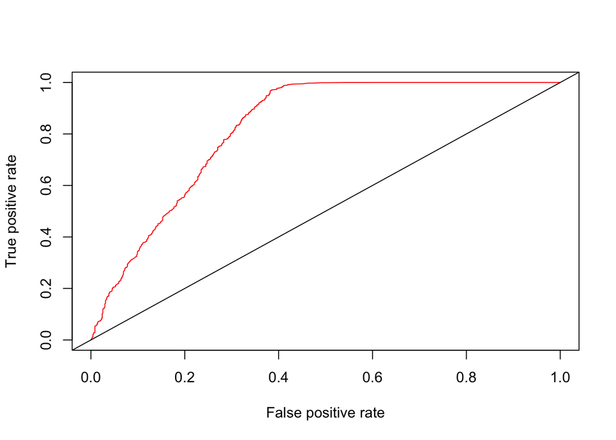

```r
fit.pred = prediction(prob, filtered_churn$churn.no)
fit.perf = performance(fit.pred,'tpr','fpr')
plot(fit.perf, col='red')
abline(a=0,b=1)
```

4.USE of classifiers - RF & KNN

Multiple curves of RF & KNN

```r
library(caret)
```

Random Forest

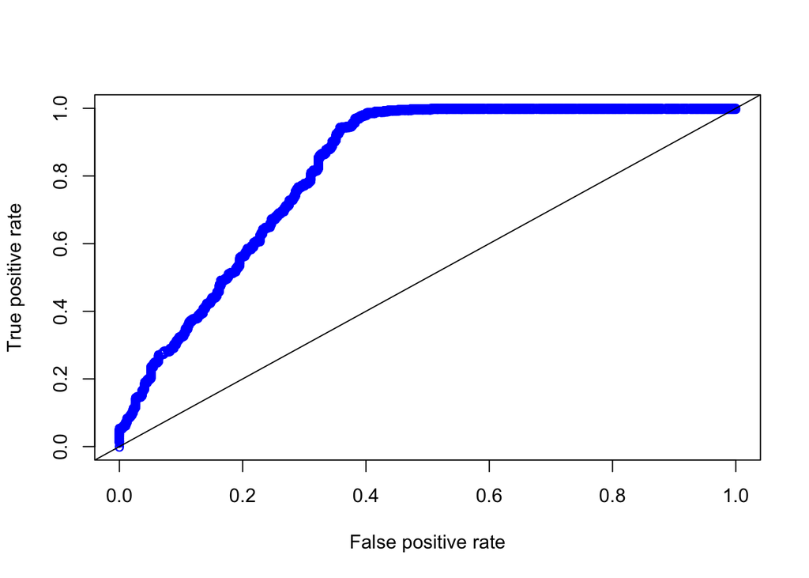

```r
library(randomForest)
RFTree <- randomForest(churn.no ~ ., data = trainset )
prob <- predict(RFTree, type='prob')[,2]
fit.pred = prediction(prob, trainset$churn.no)
fit.perf = performance(fit.pred,'tpr','fpr')
plot(fit.perf, type="o", col="blue", pch="o" )
abline(a=0,b=1)
```

KNN

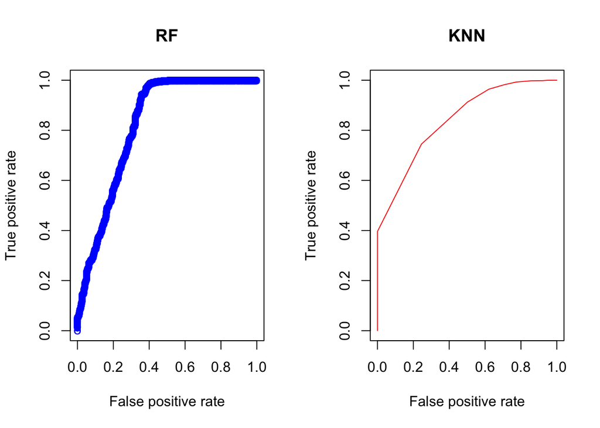

```r
knn_ffit <- knn3(churn.no ~ .,   data=trainset, k=10)
knn_prob <- predict(knn_ffit, newdata = trainset, type='prob')[,2]
fit.pred2 = prediction(knn_prob, trainset$churn.no)
fit.perf2 = performance(fit.pred2,'tpr','fpr')

old.par <- par(mfrow=c(1, 2))
plot(fit.perf, type="o", col="blue", pch="o",main="RF" )
plot(fit.perf2,col='red',main="KNN")
```

```r
par(old.par)
```

BOTH THE PLOTS in the same graph

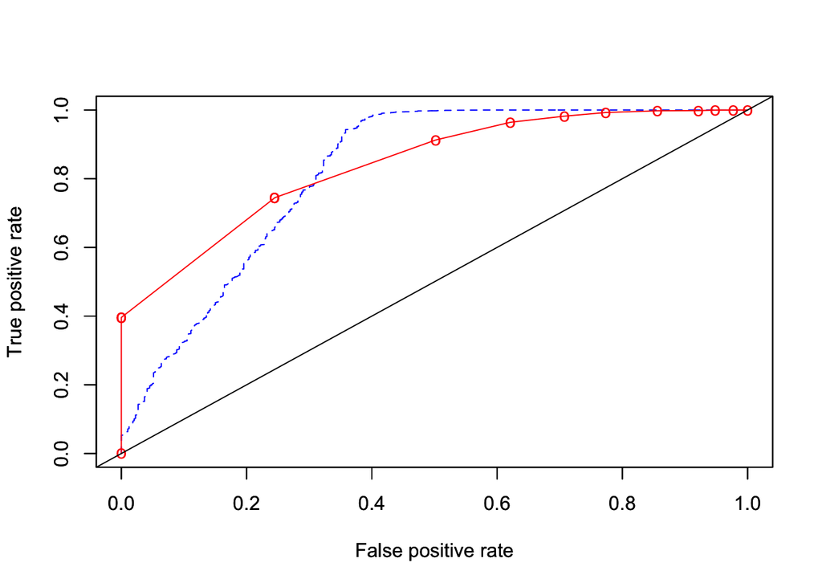

```r
plot(fit.perf, col="blue",lty=2)
par(new = TRUE)
plot(fit.perf2,col='red',type="o",pch="o")
abline(a=0,b=1)
```

AUC (Area Under the Curve) RF :

```r
fit.pred = prediction(prob, trainset$churn)
fit.perf = performance(fit.pred,'auc')
fit.perf@y.values[[1]]
```

```
## [1] 0.8198022
```

AUC (Area Under the Curve) KNN :

```r
fit.pred = prediction(knn_prob, trainset$churn)
fit.perf = performance(fit.pred,'auc')
fit.perf@y.values[[1]]
```

```
## [1] 0.8396765
```

5.HENCE by AUC we find that KNN has better performance than RF in this case as it covers more area than RF.